# MasterControl — Lead Scoring & Conversion Optimization

Author

Thomas Beck · Max Ridgeway · Astha KC

Published

January 1, 2026

# Business Problem

MasterControl sells quality management software to regulated industries, primarily through two product lines: **Mx** (manufacturing execution) and **Qx** (quality management). Leads enter the pipeline as Qualified Activity Leads (QALs) and progress through stages: Disqualified, Recycled, SQL, SQO, or Won.

The core challenge is conversion efficiency. Mx converts at approximately 12.7% versus 19.7% for Qx—a 7 percentage-point gap. With a $50 cost per sales call and $6,000 value per SQL conversion, the ability to identify which leads are most likely to convert has direct revenue impact.

# Methodology

The CRISP-DM framework structures the analysis:

- **Data Preparation:** Raw CRM data is loaded, column names are standardized, and missing categoricals are imputed with “Unknown.”
- **Feature Engineering:** Domain-informed features are created based on EDA findings—channel quality tiers, intent strength encoding, title parsing for seniority/function/scope, industry-weighted budget proxies, and role-product alignment scores.
- **Modeling:** A progression of gradient boosting models is tuned via randomized search with 5-fold stratified cross-validation, then combined in a stacking ensemble.
- **Evaluation:** AUC-ROC is the primary metric. Profit curves translate model scores into dollar-denominated business impact at various scoring thresholds.

# Data Preparation & Feature Engineering

The table below summarizes the six engineered features and their observed relationship with the target variable.

```
**Engineered Feature Validation**

| Feature               |   Correlation with Target |   Mean (Success) |   Mean (Failure) |
|:----------------------|--------------------------:|-----------------:|-----------------:|
| Intent Strength       |                    0.3281 |             2.69 |             1.26 |
| Channel Efficiency    |                    0.236  |             2.35 |             1.88 |
| Hidden Gem Flag       |                    0.1474 |             0.25 |             0.12 |
| Capital Density (log) |                   -0.0543 |             6.33 |             6.55 |
| Role-Product Match    |                    0.0815 |             0.31 |             0.22 |
| Title Bigram Count    |                    0.0471 |             0.12 |             0.09 |
```

```
**Dataset Overview**

| Metric               | Value                               |
|:---------------------|:------------------------------------|
| Total Leads          | 16,815                              |
| Target Rate (SQL+)   | 17.9%                               |
| Mx Leads             | 4,239                               |
| Qx Leads             | 12,547                              |
| Recycled (Near-Miss) | 12,067                              |
| Decision Makers      | 3,066 (18.2%)                       |
| Features Engineered  | 6 new + 8 interaction/flag features |
```

## Channel Tier Conversion

The channel tier feature captures one of the strongest patterns in the data. Premium channels (Direct/Inbound, SEO, Referrals) convert at substantially higher rates than low-value channels (External Demand Gen, Email), which account for roughly a third of pipeline volume.

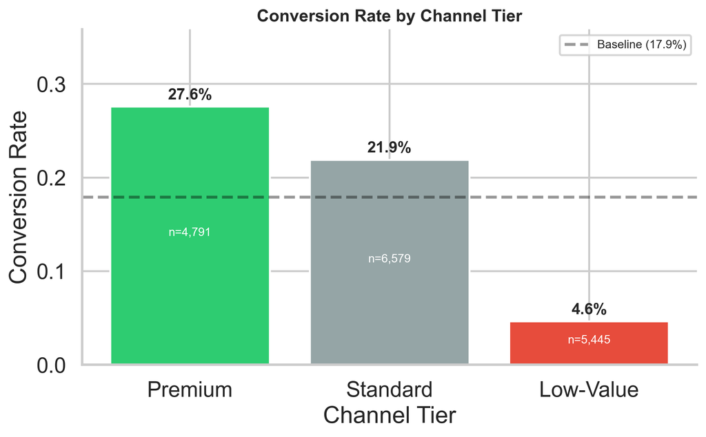

# Model Analysis

```
**Data Partition Summary**

| Partition   | Rows   | Positive Rate   |   Features |
|:------------|:-------|:----------------|-----------:|
| Train       | 10,929 | 17.9%           |         56 |
| Validation  | 2,523  | 17.9%           |         56 |
| Test        | 3,363  | 17.9%           |         56 |
```

## Candidate Models

Five algorithms are evaluated. Each is tuned with randomized search (50 iterations, 5-fold stratified CV, scored on AUC-ROC). Models use single-threaded internals while the outer search loop parallelizes across `N-1` cores to prevent thread contention.

```
**Model Comparison**

| Model            |   CV AUC (5-fold) |   Validation AUC |
|:-----------------|------------------:|-----------------:|
| CatBoost         |            0.9195 |           0.9164 |
| XGBoost          |            0.9192 |           0.9139 |
| LightGBM         |            0.918  |           0.9136 |
| GradientBoosting |            0.918  |           0.9128 |
| RandomForest     |            0.9134 |           0.9101 |
```

## Stacking Ensemble

The top three models from the validation ranking serve as base learners in a stacking ensemble with a logistic regression meta-learner. This approach captures complementary predictive patterns across algorithms.

```
**Ensemble vs Best Individual**

| Metric                     | Value            |
|:---------------------------|:-----------------|
| Stacking AUC               | 0.9164           |
| Best Individual (CatBoost) | 0.9164           |
| Improvement                | +0.0000          |
| Selected Model             | StackingEnsemble |
```

## Test Set Evaluation

The selected model is evaluated on the held-out test set, which has not been used during training or model selection.

```
**Test Set Performance (StackingEnsemble)**

| Metric            |   Value |
|:------------------|--------:|
| AUC-ROC           |  0.9138 |
| Average Precision |  0.6955 |
| Brier Score       |  0.1146 |
| Log Loss          |  0.4027 |
```

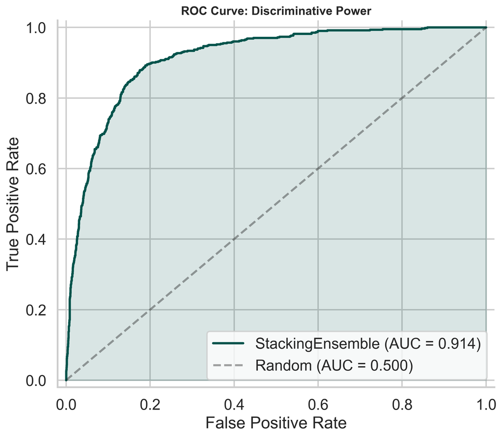

The ROC curve confirms that the model separates converters from non-converters substantially better than random. The area between the model curve and the diagonal represents the predictive lift available for lead prioritization.

# Profit Analysis

Predictive accuracy is necessary but insufficient. This section translates model scores into dollar-denominated business impact by calculating profit at every possible scoring threshold.

```
**Optimal Profit Configuration**

| Metric                  | Value      |
|:------------------------|:-----------|
| Optimal Score Threshold | 0.128      |
| Leads to Contact        | 2,315      |
| SQLs Captured           | 598        |
| Population Contacted    | 68.8%      |
| SQL Capture Rate        | 99.2%      |
| Total Cost              | $115,750   |
| Total Revenue           | $3,588,000 |
| Net Profit              | $3,472,250 |
| Lift vs Random          | 1.4x       |
```

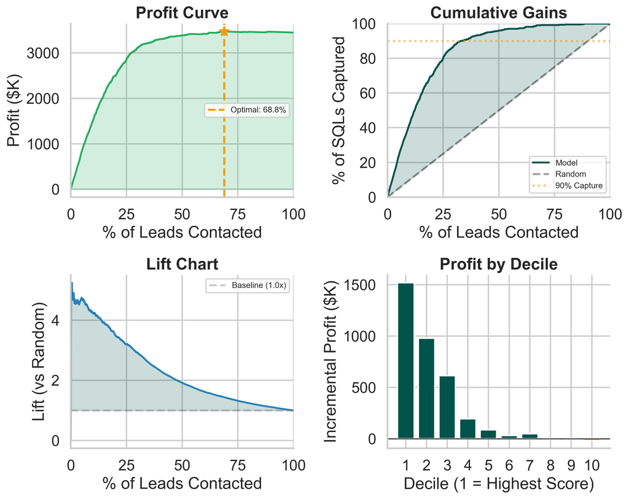

# SHAP Explainability

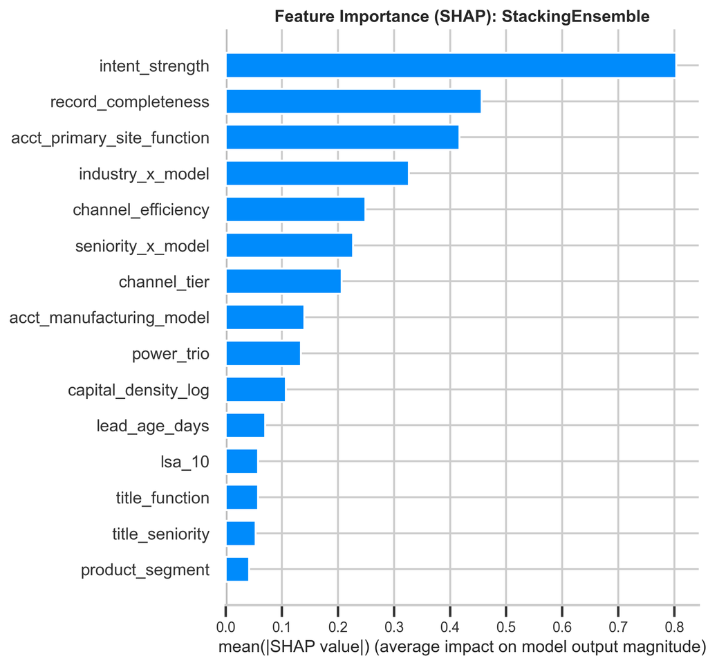

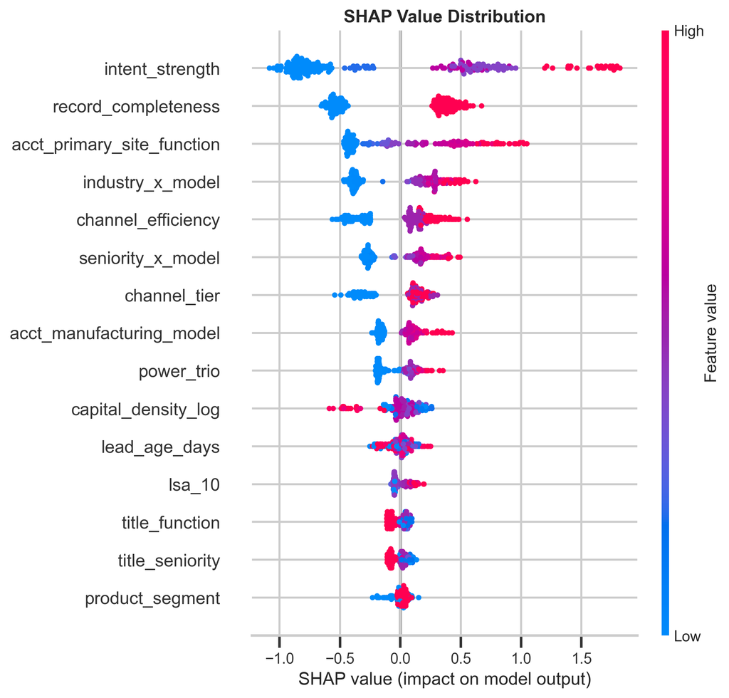

SHAP values decompose each prediction into individual feature contributions, making the model’s decision logic transparent for sponsor discussions. The bar chart shows aggregate importance, while the beeswarm plot reveals the direction and magnitude of each feature’s effect.

# Sponsor Q&A Validation

Each strategic claim is validated against the held-out test set to ensure the recommendations presented to the sponsor are data-backed.

```
**Sponsor Q&A — Data Validation**

| Question                                        | Evidence                                    | Verdict              |
|:------------------------------------------------|:--------------------------------------------|:---------------------|
| Are low-value channels underperforming?         | Low-Value: 4.5% (n=1,070) vs Premium: 27.5% | Yes — deprioritize   |
| Do stale leads (>180 days) still convert?       | Stale: 17.6% (n=2,691) vs Fresh: 26.7%      | Still viable         |
| Do hidden gem accounts convert at higher rates? | Gems: 31.5% (n=517), Lift: 1.8x             | Yes — prioritize     |
| Does capital density correlate with conversion? | Corr: -0.079, Q4/Q1 lift: 0.4x              | Weak                 |
| Does intent strength predict conversion?        | Corr: 0.311, High/Low lift: 5.9x            | Strong signal        |
| Does role-product match increase conversion?    | Matched: 23.8% (n=789), Lift: 1.5x          | Yes — route by match |
```

# Conclusion

```
**Final Model Summary**

| Metric                | Value            |
|:----------------------|:-----------------|
| Test AUC-ROC          | 0.9138           |
| Average Precision     | 0.6955           |
| Best Model            | StackingEnsemble |
| Optimal Threshold     | 0.128            |
| Max Profit (Test Set) | $3,472,250       |
| Projected Annual Lift | $268,800         |
| Calls Required        | 2,315 (69%)      |
| SQL Capture Rate      | 99%              |
| Top Decile Conversion | 76.3%            |
| Baseline Conversion   | 17.9%            |
| Runtime               | 15.9 min         |
```